# Dynamic Mode Decomposition as a Linear Model for Spatio-Temporal Systems

December 1, 2019

## The Problem

The aim is to construct linear statistical models for some process of the form

\[ \frac{d\mathbf{z}}{dt} = \mathbf{f}(\mathbf{z}) \, , \] observed at fixed locations in time to produce the “snapshot” matrices

\[ \mathbf{Z}_- = [ \mathbf{z}_{1},\mathbf{z}_{2},\ldots, \mathbf{z}_{n-1}] \quad \text{and} \quad \mathbf{Z}_+ = [\mathbf{z}_{2},\mathbf{z}_{3}, \ldots,\mathbf{z}_{n}] \, , \]

where \(\mathbf{z}_i = \mathbf{z}(t_i)\) and \(t_i - t_{i-1} = \Delta\, , \forall i\).

## Dynamic Mode Decomposition

Koopman says there exists some infinite-dimensional operator \(\mathcal{A}\) such that \(\mathcal{A}\mathbf{z} = \mathbf{f}(\mathbf{z}) = \frac{d\mathbf{z}}{dt}\). We’re practical and seek the finite-dimensional operator (matrix) \(\mathbf{A}\) such that

\[ \mathbf{Z}_+ \approx \mathbf{A}\mathbf{Z}_- \, . \] With eigenpairs \(\boldsymbol{\phi}_k\) and \(\lambda_k\) of \(\mathbf{A}\),

\[ \boxed{\mathbf{z}(t) \approx \sum^{}_{k} \beta_k \boldsymbol{\phi}_k e^{\omega_k t}} \, . \] where \(\omega_k = \log (\lambda_k) / \Delta\).

## Low-Rank Approximation

The best-fit operator \(\mathbf{A} = \mathbf{Z}_+ \mathbf{Z}_-^{\dagger}\) is too unwieldy, so use low-rank, singular-value decomposition

\[ \mathbf{Z}^{\dagger}_- \approx \mathbf{V}_r\boldsymbol{\Sigma}^{-1}_r \mathbf{U}^*_r \] to define the low-rank operator

\[ \tilde{\mathbf{A}} = \mathbf{U}^*_r \mathbf{A} \mathbf{U}_r = \mathbf{U}^*_r \mathbf{Z}_+ \, . \] The eigendecomposition \(\tilde{\mathbf{A}}\mathbf{W} = \mathbf{W}\boldsymbol{\Lambda}\) yields eigenvalues \(\lambda_i\) and eigenvectors \(\boldsymbol{\Phi} = \mathbf{Z}_+ \mathbf{V}_r\boldsymbol{\Sigma}_r^{-1}\mathbf{W}\) of \(\mathbf{A}\).

Because modes are complex, (1) keep Re and Im parts of pairs separately or (2) keep only Re component.

## Demonstration Problem

To illustrate, maximum temperatures at 132 weather stations in 07/93 were modeled using NOAA data packaged for [Spatio-Temporal Statistics with R](https://spacetimewithr.org/).

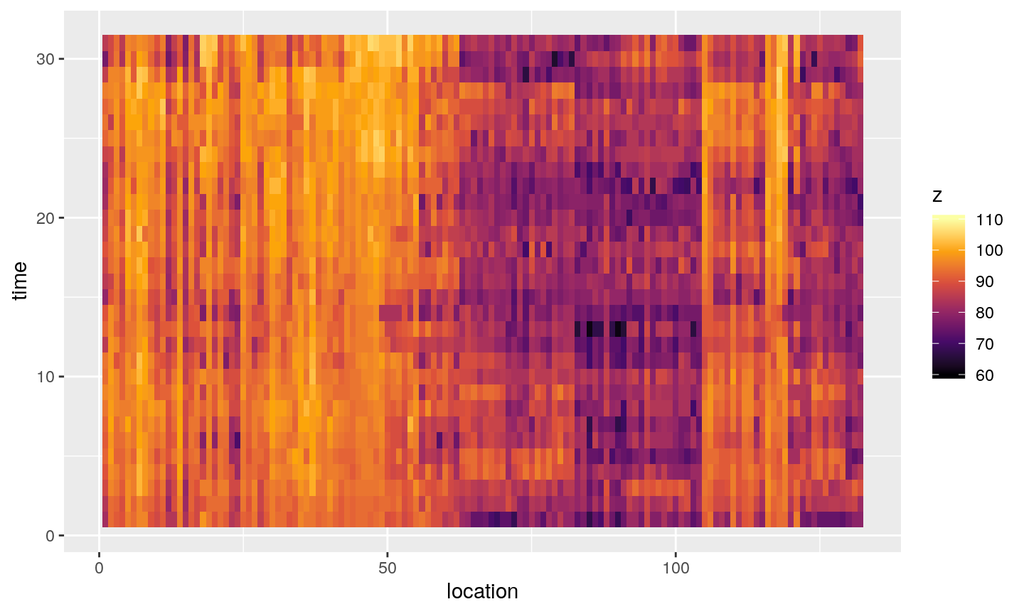

## Inspecting DMD modes

Here, four DMD modes using optimal rank (i.e., 4) and discarding imaginary components of complex-conjugate pairs:

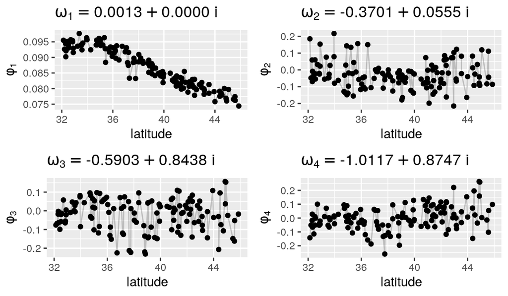

Note the near-zero frequency of mode 1, which indicates a nearly time-invariant contribution.

## Linear Model

Reorganize the observations \(\mathbf{Z}\) as

\[ \boldsymbol{\zeta} = [z_{11}, z_{21}, \ldots z_{m1}, z_{12}, \ldots, z_{mn}] \, . \]

Then let

\[ \boldsymbol{\zeta} = \boldsymbol{\Psi}\boldsymbol{\beta} + \boldsymbol{\varepsilon} \, , \] where \(\boldsymbol{\varepsilon} \sim N(0, \mathbf{I}\sigma^2_{\varepsilon})\) and the columns of \(\boldsymbol{\Psi}\) are defined as

\[ \boldsymbol{\psi}_k = [\phi_{ki} e^{\omega_k t_j} \, \text{for} \, i =1\ldots m \, \text{for} \, j = 1\ldots n]' \, . \]

## Reconstructing \(\mathbf{Z}\) with DMD Basis

Using all data, approximate \(\mathbf{Z}\); shown at right is temperature at station 14943.

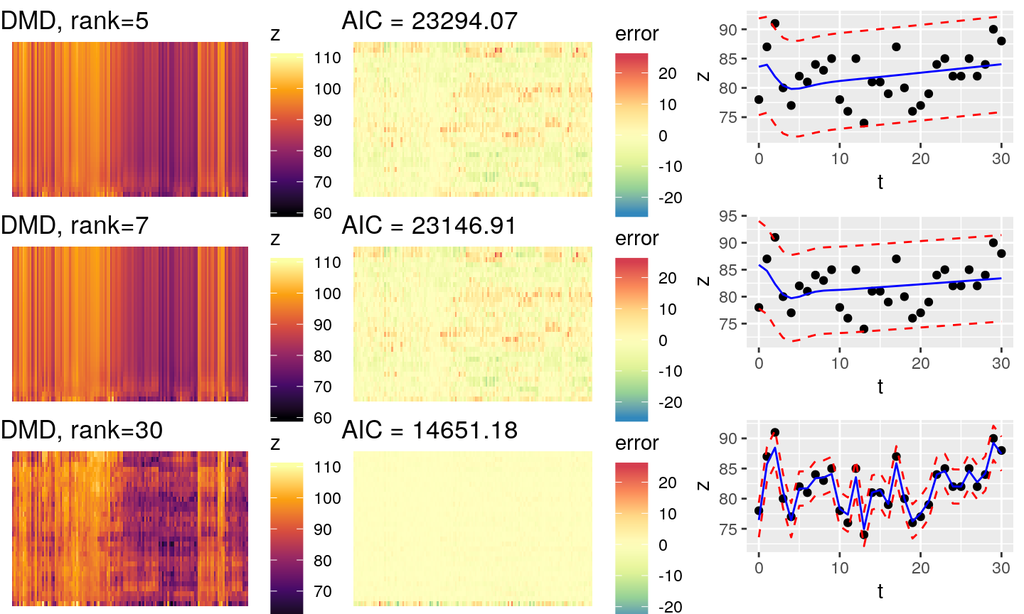

## Reconstructing \(\mathbf{Z}\) with Poly. Basis

Using all data, approximate \(\mathbf{Z}\); shown at right is temperature at station 14943.

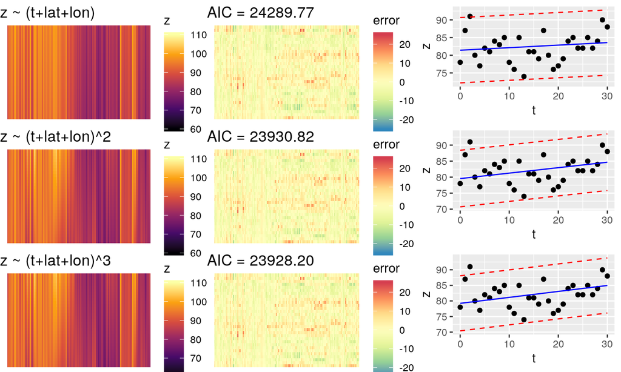

## Predicting \(\mathbf{Z}\) with DMD Basis

Now, use only first 28 observations. Shown at right is temperature at station 14943.

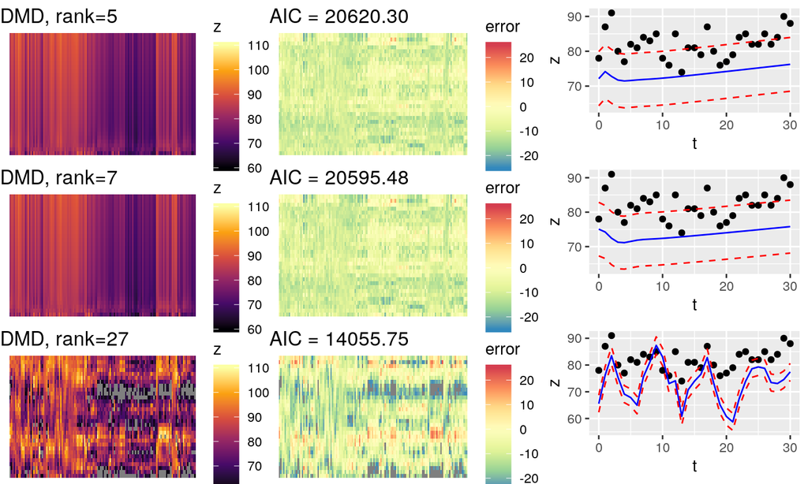

## Predicting \(\mathbf{Z}\) with Poly. Basis

Now, use only first 28 observations. Shown at right is temperature at station 14943.

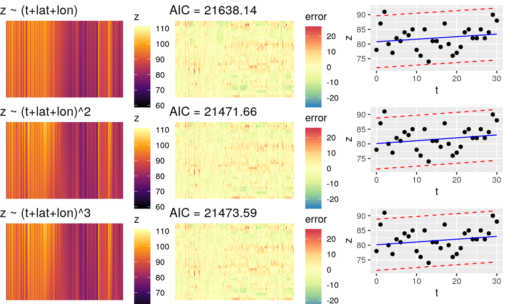

## A Bit on Model Selection

Compare models with (A) rank-\(r\) SVD and basis, elimating pairs, (B) rank-\(r\) SVD and basis, keeping pairs, and (C) rank-30 SVD, “optimal” rank-\(r\) basis:

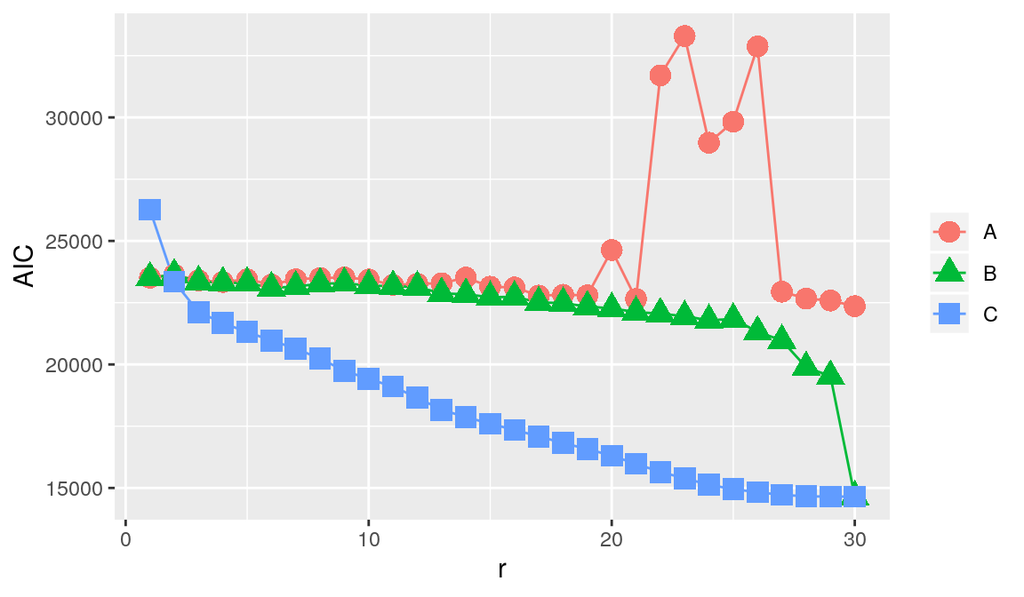

## Conclusions, etc.

- Mechanics of DMD for discrete-in-space, continuous-in-time modeling demonstrated.
- DMD modes can capture a lot of information but may lead to overfitting (as suggested by predictions)
- DMD modes coupled with spatial coordinates may yield low-rank, spatial GPs
- The whole process looks pretty similar to principal oscillation patterns (POPs)…